# eeg_mri_with_unet

### What is EEG(electroencephalography)

1. Our brain works with electrical signal generated and transmitted by the brain neurons, and this electrical activity changes based on the stimulus with which we interact, EEG is the process of recording this electrical activity, in the form of some signals.
2. To read this electrical activity special electrodes are used, basically a set of electrodes is placed over the head to record the electrical activity as waveforms.
3. Certain waveforms recorded by EEG device are of great interest for study of the human brain functioning and they lie under the frequency ranges as follows :

3.1. **Delta:** has a frequency of 3 Hz or below. It tends to be the highest in amplitude and the slowest waves.  
3.2. **Theta:** has a frequency of 3.5 to 7.5 Hz and is classified as "slow" activity.  
3.3. **Alpha:** has a frequency between 7.5 and 13 Hz.  
3.4. **Beta:** beta activity is "fast" activity. It has a frequency of 14 and greater Hz.

**Note: To convert the eeg data into 2D eeg-cap image use the video given at this link :** https://neuroimage.usc.edu/brainstorm/Screenshots

1. **Electrodes in EEG :** eeg has electrodes which records the frequency at various time intervals, which basically depends upon sampling frequency i.e. the rate at which electrodes are programmed to read the frequencies. These electrodes are called as **Channels** and frequencies of these channels is recoreded in the dataset at the rate of sampling frequency.
2. **Epoch :** Since the data of the eeg can be sampled for very long period of time and thus for a single patient it would be difficult to read the whole data, thus these data would be divided into parts of equal time intervals, these part is known as an **epoch**
3. **Data_shape_of_eeg :** The data read from eeg is a numpy array, where **1st dimension represent the number of patients whose data have been collected, 2nd dimesnion represent the number of epochs in which that data is divided, 3rd dimension represent the number of channels in which all the electrodes used have been divided, and 4th dimension tells the frequencies values collected at various time intervals(based on the sampling frequencies used)**

### Code for converting EEG data to mri results

```python
import os
import mne # main library for eeg analysis
import numpy as np
from glob import glob # to extract proper paths
import pandas as pd
import matplotlib.pyplot as plt
from pathlib import Path
import nibabel as nib # main library of fmri
from PIL import Image
from tqdm import tqdm
```

#### Plotting channel wise each frequency data

```python
file_paths = glob('EEG_to_fMRI/data_set/EEG1/*/raw/*.vhdr')
file_paths
```

```
['EEG_to_fMRI/data_set/EEG1/39/raw/20130501390002.vhdr',
 'EEG_to_fMRI/data_set/EEG1/47/raw/20130710470002.vhdr',
 'EEG_to_fMRI/data_set/EEG1/48/raw/20130717480002.vhdr',
 'EEG_to_fMRI/data_set/EEG1/32/raw/20130410320002.vhdr',
 'EEG_to_fMRI/data_set/EEG1/36/raw/20130425360002.vhdr',
 'EEG_to_fMRI/data_set/EEG1/46/raw/20130703460002.vhdr',
 'EEG_to_fMRI/data_set/EEG1/40/raw/20130510400002.vhdr',
 'EEG_to_fMRI/data_set/EEG1/45/raw/20130627450002.vhdr',
 'EEG_to_fMRI/data_set/EEG1/37/raw/20130426370002.vhdr',
 'EEG_to_fMRI/data_set/EEG1/42/raw/20130523420002.vhdr',
 'EEG_to_fMRI/data_set/EEG1/38/raw/20130105380002.vhdr',
 'EEG_to_fMRI/data_set/EEG1/35/raw/20130424350002.vhdr',
 'EEG_to_fMRI/data_set/EEG1/44/raw/20130605440002.vhdr',
 'EEG_to_fMRI/data_set/EEG1/50/raw/20131003_500002.vhdr',
 'EEG_to_fMRI/data_set/EEG1/43/raw/20130529430002.vhdr',
 'EEG_to_fMRI/data_set/EEG1/49/raw/20130918490002.vhdr']
```

```python
def extracting_data_for_particular_freq(file_path, l_freq, h_freq):

    data = mne.io.read_raw_brainvision(file_path, preload=True,verbose=False)
    data = data.pick_types(eeg=True, verbose=False)
    data = data.filter(l_freq=l_freq,
                       h_freq=h_freq,
                       verbose=False)

    # start is the start time, and duration gives us start+duration=end_time
    for i in range(0,64,8):
        data.plot(start=0, duration=50, order=[i, i+1, i+2, i+3, i+4, i+5, i+6, i+7])
```

```
Using matplotlib as 2D backend.
```

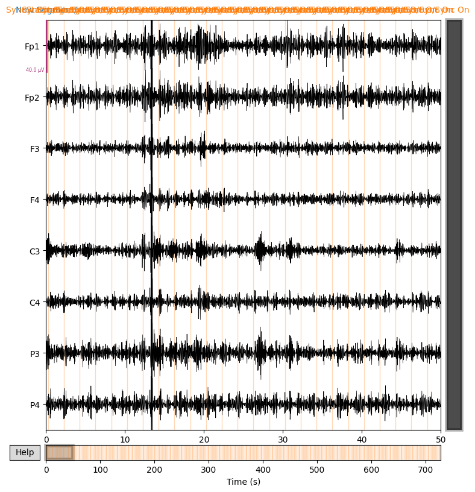

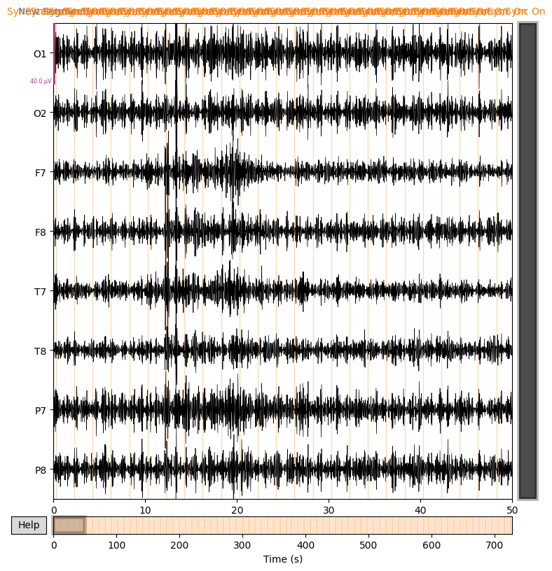

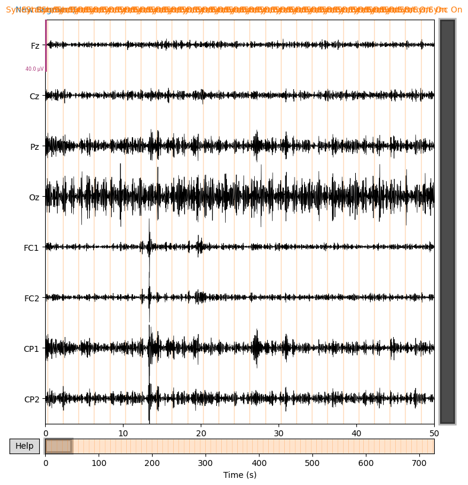

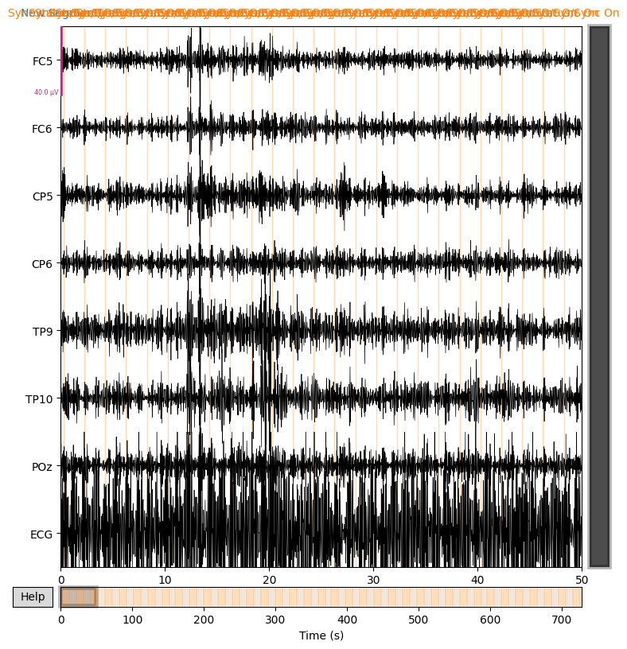

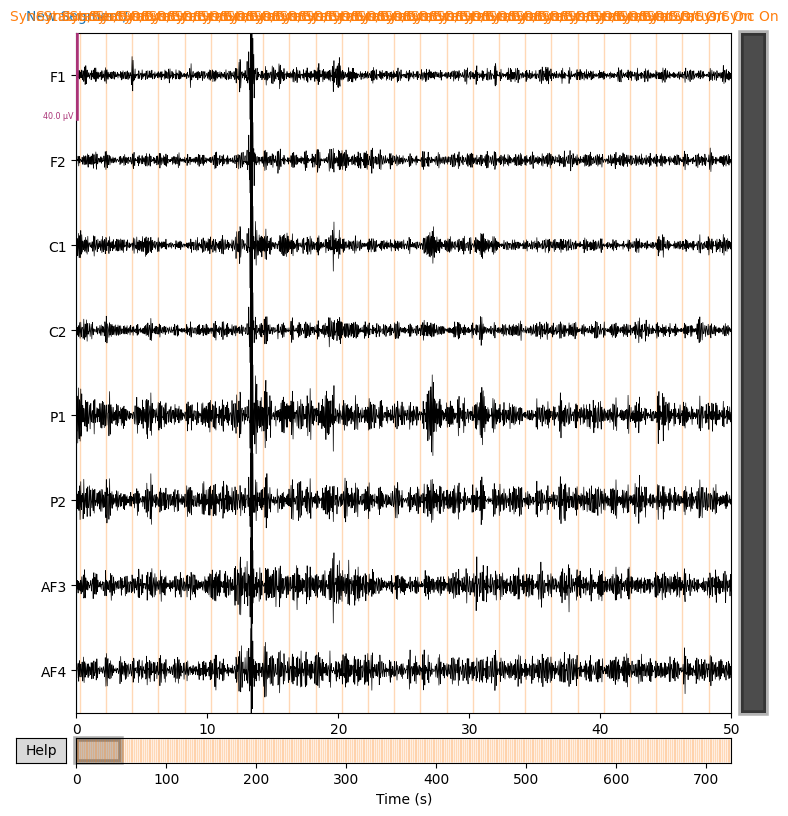

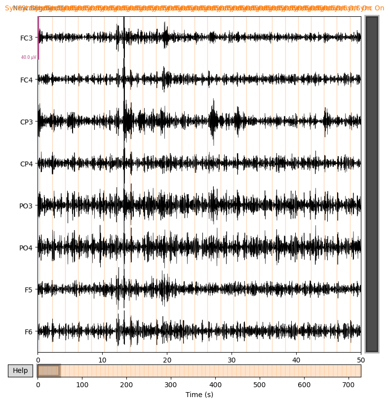

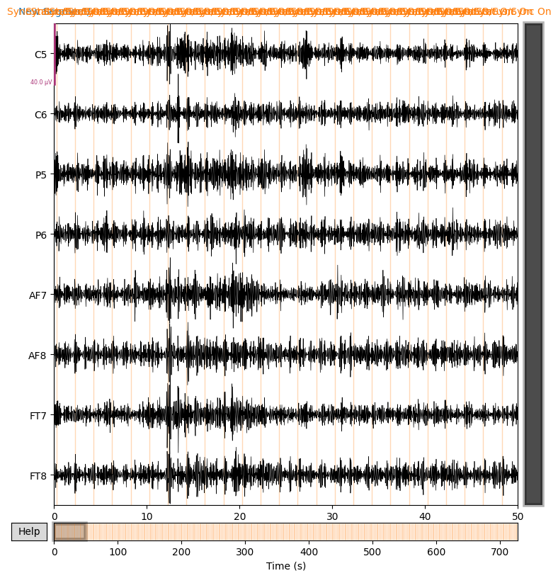

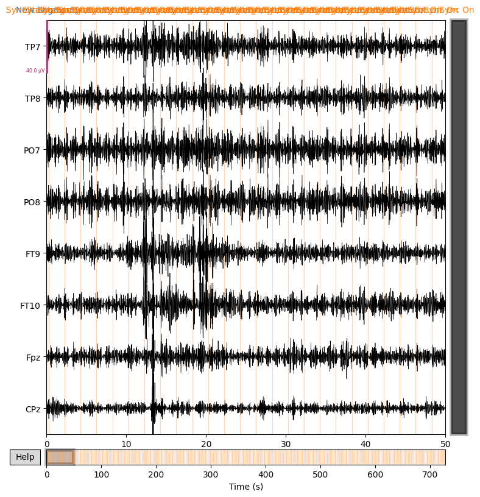

```python
extracting_data_for_particular_freq(file_paths[0], 8, 13)
```

#### Code block for getting 30 samples of 64x64 from each patients eeg

```python
def func_to_split_eeg_into_x(sample_data, x): # trying to split it into x
    """this function is already available in the name of
       np.array_split(), will implement this in future
       """
    """x here means the parts we want to split the data
       to create x data from a single patient
       """
    sample_data_splits = list()
    j=0
    step = int(sample_data.shape[-1]*1/x)

    while (j*step)<sample_data.shape[-1]:
        sample_data_splits.append(sample_data[:, j*step : (j+1)*step])
        j+=1

    return np.array(sample_data_splits, dtype=object)


def get_x_x64x64_eeg(data, len_crop=648, freq_range_list=[(8,13),(13,40),(4,8),(0.5,4)]):
    """data should be an object obtained after executing below
       two lines on the eeg raw data file name,
       data = mne.io.read_raw_brainvision(file_path, preload=True,verbose=False)
       data = data.pick_types(eeg=True, verbose=False)

       and freq_range_list
       should be a list containing low and high freq tuple
       of each band i.e alpha, beta, theta and delta"""

    # 648 should be the length which is needed for corresponding
    # mri images.
    # this has been calculated on the basis of TR and TE of MRI
    data = data.crop(len_crop, verbose=False)   # keeping first len_crop sec data only

    data_alpha = data.copy()
    data_beta  = data.copy()
    data_theta = data.copy()
    data_delta = data.copy()

    data_alpha = data_alpha.filter(l_freq=freq_range_list[0][0],
                             h_freq=freq_range_list[0][1],
                             verbose=False)
   # frequency above 40 has not been considered
    data_beta  = data_beta.filter(l_freq=freq_range_list[1][0],
                             h_freq=freq_range_list[1][1],
                             verbose=False)

    data_theta = data_theta.filter(l_freq=freq_range_list[2][0],
                             h_freq=freq_range_list[2][1],
                             verbose=False)

    data_delta = data_delta.filter(l_freq=freq_range_list[3][0],
                             h_freq=freq_range_list[3][1],
                             verbose=False)
    x = 30 # it should be the number of parts in which we want to divide the data
           # of a single patient to create x data-points from them

    data_alpha = np.array_split(data_alpha.get_data(verbose=False), x, axis=-1)
    data_beta  = np.array_split(data_beta.get_data(verbose=False), x, axis=-1)
    data_theta = np.array_split(data_theta.get_data(verbose=False), x, axis=-1)
    data_delta = np.array_split(data_delta.get_data(verbose=False), x, axis=-1)

    #print(len(data_alpha))

    # since we are using four bands(alpha, beta, delta and theta) therefore to get
    # 64 points i need 16 points
    # from each band as 16x4=64, thus dividing each part for each frequency band
    # into 16 parts and then taking mean of each part(among the 16 parts), to
    # convert it into a single data-point

    # splitting

    points = 16
    ind = 0
    for alpha, beta, theta, delta in zip(data_alpha, data_beta, data_theta, data_delta):
        data_alpha[ind] = np.array_split(alpha, points, axis=-1)
        data_beta [ind] = np.array_split(beta , points, axis=-1)
        data_theta[ind] = np.array_split(theta, points, axis=-1)
        data_delta[ind] = np.array_split(delta, points, axis=-1)
        ind+=1


    # taking mean as mentioned above
    ind = 0
    for alpha, beta, theta, delta in zip(data_alpha, data_beta, data_theta, data_delta):
        # transposing them to convert from 30x16x64 to 30x64x16
        data_alpha[ind] = np.array([sample.mean(axis=-1) for sample in alpha]).T
        data_beta [ind] = np.array([sample.mean(axis=-1) for sample in  beta]).T
        data_theta[ind] = np.array([sample.mean(axis=-1) for sample in theta]).T
        data_delta[ind] = np.array([sample.mean(axis=-1) for sample in delta]).T
        ind+=1

    final_data = np.concatenate((data_alpha, data_beta, data_theta, data_delta), axis=-1)

    return final_data

def get_df_for_eeg_data(file_paths):
    final_data = list()
    final_name = list()
    parts = 30
    for i, file_path in enumerate(file_paths):
        try:
            data = mne.io.read_raw_brainvision(file_path, preload=True,verbose=False)
            data = data.pick_types(eeg=True, verbose=False)
            data = get_x_x64x64_eeg(data)
            patient_no = file_path.split(r'/')[-3]
        except:
            continue

        final_data.append(data)
        final_name.append([f'patient_no_{patient_no}_split_no_{i+1}' for i in range(parts)])

    final_data = np.concatenate(np.array(final_data))
    final_name = np.concatenate(np.array(final_name))

    df = pd.DataFrame(data={'patient_no_split_no': list(final_name), '64x64_matrix': list(final_data)})

    return df
```

#### Code block for getting a single frequency only and that to in shape of 64x64

```python
def get_x_x64x64_eeg_for_single_freq(data, len_crop=648, freq_range_list=[(9,11)]):
    """data should be an object obtained after executing below
       two lines on the eeg raw data file name,
       data = mne.io.read_raw_brainvision(file_path, preload=True,verbose=False)
       data = data.pick_types(eeg=True, verbose=False)

       and freq_range_list
       should be a list containing low and high freq tuple
       of each band i.e alpha, beta, theta and delta"""

    # 648 should be the length which is needed for corresponding
    # mri images.
    # this has been calculated on the basis of TR and TE of MRI
    data = data.crop(len_crop, verbose=False)   # keeping first len_crop sec data only

    data_alpha = data.copy()

    data_alpha = data_alpha.filter(l_freq=freq_range_list[0][0],
                             h_freq=freq_range_list[0][1],
                             verbose=False)
   # frequency above 40 has not been considered
    x = 30 # it should be the number of parts in which we want to divide the data
           # of a single patient to create x data-points from them

    data_alpha = np.array_split(data_alpha.get_data(verbose=False), x, axis=-1)

    # splitting

    points = 64
    ind = 0
    for alpha in data_alpha:
        data_alpha[ind] = np.array_split(alpha, points, axis=-1)
        ind+=1


    # taking mean as mentioned above
    ind = 0
    for alpha in data_alpha:
        # transposing them to convert from 30x16x64 to 30x64x16
        data_alpha[ind] = np.array([sample.mean(axis=-1) for sample in alpha]).T
        ind+=1

    final_data = np.array(data_alpha)

    return final_data


def get_df_for_eeg_data_for_single_freq(file_paths):
    final_data = list()
    final_name = list()
    parts = 30
    for i, file_path in enumerate(file_paths):
        try:
            data = mne.io.read_raw_brainvision(file_path, preload=True,verbose=False)
            data = data.pick_types(eeg=True, verbose=False)
            data = get_x_x64x64_eeg_for_single_freq(data)
            patient_no = file_path.split(r'/')[-3]
        except:
            continue

        final_data.append(data)
        final_name.append([f'patient_no_{patient_no}_split_no_{i+1}' for i in range(parts)])

    final_data = np.concatenate(np.array(final_data))
    final_name = np.concatenate(np.array(final_name))

    df = pd.DataFrame(data={'patient_no_split_no': list(final_name), '64x64_matrix': list(final_data)})

    return df
```

```python
#eeg_df = get_df_for_eeg_data(file_paths) #run this if we want to get for all four
# frequency bands
eeg_df = get_df_for_eeg_data_for_single_freq(file_paths)
```

```python
eeg_df.shape
```

```
(450, 2)
```

```python
eeg_df['64x64_matrix'][0].shape
```

```
(64, 64)
```

**Note : Row represents channel and column represents time in the above matrix**

#### Reading MRI data

```python
def get_df_for_mri_data(input_file_list):

    image_count = 0
    final_name = list()
    final_data = list()

    for path in tqdm(input_file_list):
        # no of parts in which data of single patient need to be
        # splitted
        parts = 30
        try:
            img = nib.load(path).get_fdata()
            patient_no = path.split(r'/')[-2]

            if len(img.shape)==4:
                start = 9
                stop = 301
                step = start+1
                slice_no = 14 # mid slice is 15, its index is 14
                img = img[:,:,slice_no,list(range(start,stop,step))]
                new_img = list()
                for image_no in range(parts):
                    new_img.append(img[:,:,image_no])
                final_data.append(new_img)
                final_name.append([f'patient_no_{patient_no}_split_no_{i+1}' for i in range(parts)])

        except:
            continue

    final_data = np.concatenate(np.array(final_data))
    final_name = np.concatenate(np.array(final_name))

    df = pd.DataFrame(data={'patient_no_split_no': list(final_name), 'fmri_matrix': list(final_data)})

    return df
```

```python
mri_path = glob('EEG_to_fMRI/data_set/fMRI/*/*.gz')
```

```python
mri_path
```

```
['EEG_to_fMRI/data_set/fMRI/39/3_nw_mepi_rest_with_cross.nii.gz',
 'EEG_to_fMRI/data_set/fMRI/39/2_fl3D_t1_sag_fun_defaced.nii.gz',
 'EEG_to_fMRI/data_set/fMRI/47/3_nw_mepi_rest_with_cross.nii.gz',
 'EEG_to_fMRI/data_set/fMRI/47/2_fl3D_t1_sag_fun_defaced.nii.gz',
 'EEG_to_fMRI/data_set/fMRI/48/3_nw_mepi_rest_with_cross.nii.gz',
 'EEG_to_fMRI/data_set/fMRI/48/2_fl3D_t1_sag_fun_defaced.nii.gz',
 'EEG_to_fMRI/data_set/fMRI/32/3_nw_mepi_rest_with_cross.nii.gz',
 'EEG_to_fMRI/data_set/fMRI/32/2_fl3D_t1_sag_fun_defaced.nii.gz',
 'EEG_to_fMRI/data_set/fMRI/36/3_nw_mepi_rest_with_cross.nii.gz',
 'EEG_to_fMRI/data_set/fMRI/36/2_fl3D_t1_sag_fun_defaced.nii.gz',
 'EEG_to_fMRI/data_set/fMRI/46/3_nw_mepi_rest_with_cross.nii.gz',
 'EEG_to_fMRI/data_set/fMRI/46/2_fl3D_t1_sag_fun_defaced.nii.gz',
 'EEG_to_fMRI/data_set/fMRI/40/05_nw_mepi_rest_with_cross.nii.gz',
 'EEG_to_fMRI/data_set/fMRI/40/04_fl3D_t1_sag_fun_defaced.nii.gz',
 'EEG_to_fMRI/data_set/fMRI/45/3_nw_mepi_rest_with_cross.nii.gz',
 'EEG_to_fMRI/data_set/fMRI/45/2_fl3D_t1_sag_fun_defaced.nii.gz',
 'EEG_to_fMRI/data_set/fMRI/37/3_nw_mepi_rest_with_cross.nii.gz',
 'EEG_to_fMRI/data_set/fMRI/37/2_fl3D_t1_sag_fun_defaced.nii.gz',
 'EEG_to_fMRI/data_set/fMRI/42/3_nw_mepi_rest_with_cross.nii.gz',
 'EEG_to_fMRI/data_set/fMRI/42/2_fl3D_t1_sag_fun_defaced.nii.gz',
 'EEG_to_fMRI/data_set/fMRI/38/3_nw_mepi_rest_with_cross.nii.gz',
 'EEG_to_fMRI/data_set/fMRI/38/2_fl3D_t1_sag_fun_defaced.nii.gz',
 'EEG_to_fMRI/data_set/fMRI/35/3_nw_mepi_rest_with_cross.nii.gz',
 'EEG_to_fMRI/data_set/fMRI/35/2_fl3D_t1_sag_fun_defaced.nii.gz',
 'EEG_to_fMRI/data_set/fMRI/44/3_nw_mepi_rest_with_cross.nii.gz',
 'EEG_to_fMRI/data_set/fMRI/44/2_fl3D_t1_sag_fun_defaced.nii.gz',
 'EEG_to_fMRI/data_set/fMRI/50/3_nw_mepi_rest_with_cross.nii.gz',
 'EEG_to_fMRI/data_set/fMRI/50/2_fl3D_t1_sag_fun_defaced.nii.gz',
 'EEG_to_fMRI/data_set/fMRI/43/3_nw_mepi_rest_with_cross.nii.gz',
 'EEG_to_fMRI/data_set/fMRI/43/2_fl3D_t1_sag_fun_defaced.nii.gz',
 'EEG_to_fMRI/data_set/fMRI/49/3_nw_mepi_rest_with_cross.nii.gz',
 'EEG_to_fMRI/data_set/fMRI/49/2_fl3D_t1_sag_fun_defaced.nii.gz']
```

```python
fmri_df = get_df_for_mri_data(mri_path)
```

```python
fmri_df
```

|  | patient_no_split_no | fmri_matrix |
| --- | --- | --- |
| 0 | patient_no_39_split_no_1 | [[0.0, 0.0, 0.0, 0.0, 0.0, 0.0, 0.0, 0.0, 0.0,... |
| 1 | patient_no_39_split_no_2 | [[0.0, 0.0, 0.0, 0.0, 0.0, 0.0, 0.0, 0.0, 0.0,... |
| 2 | patient_no_39_split_no_3 | [[0.0, 0.0, 0.0, 0.0, 0.0, 0.0, 0.0, 0.0, 0.0,... |
| 3 | patient_no_39_split_no_4 | [[0.0, 0.0, 0.0, 0.0, 0.0, 0.0, 0.0, 0.0, 0.0,... |
| 4 | patient_no_39_split_no_5 | [[0.0, 0.0, 0.0, 0.0, 0.0, 0.0, 0.0, 0.0, 0.0,... |
| ... | ... | ... |
| 475 | patient_no_49_split_no_26 | [[0.0, 0.0, 0.0, 0.0, 0.0, 0.0, 0.0, 0.0, 0.0,... |
| 476 | patient_no_49_split_no_27 | [[0.0, 0.0, 0.0, 0.0, 0.0, 0.0, 0.0, 0.0, 0.0,... |
| 477 | patient_no_49_split_no_28 | [[0.0, 0.0, 0.0, 0.0, 0.0, 0.0, 0.0, 0.0, 0.0,... |
| 478 | patient_no_49_split_no_29 | [[0.0, 0.0, 0.0, 0.0, 0.0, 0.0, 0.0, 0.0, 0.0,... |
| 479 | patient_no_49_split_no_30 | [[0.0, 0.0, 0.0, 0.0, 0.0, 0.0, 0.0, 0.0, 0.0,... |

480 rows × 2 columns

```python
fmri_df.shape
```

```
(480, 2)
```

```python
final_df = pd.merge(eeg_df, fmri_df, how='inner', on=['patient_no_split_no'])
```

```python
final_df
```

|  | patient_no_split_no | 64x64_matrix | fmri_matrix |
| --- | --- | --- | --- |
| 0 | patient_no_39_split_no_1 | [[-6.063892688815142e-05, 4.530124006445152e-0... | [[0.0, 0.0, 0.0, 0.0, 0.0, 0.0, 0.0, 0.0, 0.0,... |
| 1 | patient_no_39_split_no_2 | [[-2.8286552218063074e-06, -2.496603727194178e... | [[0.0, 0.0, 0.0, 0.0, 0.0, 0.0, 0.0, 0.0, 0.0,... |
| 2 | patient_no_39_split_no_3 | [[1.2056318201482887e-06, -3.614116734166372e-... | [[0.0, 0.0, 0.0, 0.0, 0.0, 0.0, 0.0, 0.0, 0.0,... |
| 3 | patient_no_39_split_no_4 | [[-8.541717041867201e-07, 4.2927598872456096e-... | [[0.0, 0.0, 0.0, 0.0, 0.0, 0.0, 0.0, 0.0, 0.0,... |
| 4 | patient_no_39_split_no_5 | [[9.924906717392082e-07, 1.3685421153641766e-0... | [[0.0, 0.0, 0.0, 0.0, 0.0, 0.0, 0.0, 0.0, 0.0,... |
| ... | ... | ... | ... |
| 445 | patient_no_49_split_no_26 | [[-9.151081314270459e-07, 6.425814219455144e-0... | [[0.0, 0.0, 0.0, 0.0, 0.0, 0.0, 0.0, 0.0, 0.0,... |
| 446 | patient_no_49_split_no_27 | [[-2.390007441900911e-06, -9.343212886622807e-... | [[0.0, 0.0, 0.0, 0.0, 0.0, 0.0, 0.0, 0.0, 0.0,... |
| 447 | patient_no_49_split_no_28 | [[1.0842421231249934e-06, -4.9860946524312e-08... | [[0.0, 0.0, 0.0, 0.0, 0.0, 0.0, 0.0, 0.0, 0.0,... |
| 448 | patient_no_49_split_no_29 | [[-2.231608209831522e-06, -3.995668489853067e-... | [[0.0, 0.0, 0.0, 0.0, 0.0, 0.0, 0.0, 0.0, 0.0,... |
| 449 | patient_no_49_split_no_30 | [[-1.9298077225792625e-06, -7.104053438090597e... | [[0.0, 0.0, 0.0, 0.0, 0.0, 0.0, 0.0, 0.0, 0.0,... |

450 rows × 3 columns

```python
final_df['fmri_matrix'][1].shape
```

```
(64, 64)
```

```python
final_df['64x64_matrix'][1].shape
```

```
(64, 64)
```

```python
final_data_array = final_df[['64x64_matrix','fmri_matrix']].to_numpy()
final_data_array.shape
```

```
(450, 2)
```

```python
eeg_array = final_data_array[:,0]
mri_array = final_data_array[:,1]
```

```python
eeg_array = np.array([item for item in eeg_array])
eeg_array = eeg_array[:,:,:, np.newaxis]
eeg_array.shape
```

```
(450, 64, 64, 1)
```

```python
mri_array = np.array([item for item in mri_array])
mri_array = mri_array[:,:,:, np.newaxis]
mri_array.shape
```

```
(450, 64, 64, 1)
```

### Upto this we dealt with data prepartion and this part should be run whenever we need data

### Using Unet as autoencoders from here, so this part should be run separately

```python
from numpy import load
from numpy import zeros
import datetime
from numpy import ones
import tensorflow as tf
from numpy.random import randint
from tensorflow.keras.optimizers import Adam
from tensorflow.keras.initializers import RandomNormal
from tensorflow.keras.models import Model
from tensorflow.keras.layers import Input
from tensorflow.keras.layers import Conv2D
from tensorflow.keras.layers import Conv2DTranspose
from tensorflow.keras.layers import LeakyReLU
from tensorflow.keras.layers import Activation
from tensorflow.keras.layers import Concatenate
from tensorflow.keras.layers import Dropout
from tensorflow.keras.layers import BatchNormalization
from tensorflow.keras.layers import LeakyReLU
from matplotlib import pyplot
```

[output not shown]

```python
tf.keras.backend.clear_session()
```

```python
# define an encoder block
def define_encoder_block(layer_in, n_filters, batchnorm=True, stride=2):
    # weight initialization
    init = RandomNormal(stddev=0.02)
    # add downsampling layer
    g = Conv2D(n_filters, (4,4), strides=stride, padding='same', kernel_initializer=init)(layer_in)
    # conditionally add batch normalization
    if batchnorm:
        g = BatchNormalization()(g, training=True)
    # leaky relu activation
    g = LeakyReLU(alpha=0.2)(g)
    return g

# define a decoder block
def decoder_block(layer_in, skip_in, n_filters, dropout=True, stride=2):
    # weight initialization
    init = RandomNormal(stddev=0.02)
    # add upsampling layer
    g = Conv2DTranspose(n_filters, (4,4), strides=stride, padding='same', kernel_initializer=init)(layer_in)
    # add batch normalization
    g = BatchNormalization()(g, training=True)
    # conditionally add dropout
    if dropout:
        #g = Dropout(0.5)(g, training=True)
        skip_in = Dropout(0.5)(skip_in, training=True)
    # merge with skip connection
    g = Concatenate()([g, skip_in])
    # relu activation
    g = Activation('relu')(g)
    return g

# define the standalone generator model
def define_model(image_shape=(256,256,1)):
    # weight initialization
    init = RandomNormal(stddev=0.02)
    # image input
    in_image = Input(shape=image_shape)
    # encoder model
    e1 = define_encoder_block(in_image, 64, batchnorm=False)
    e2 = define_encoder_block(e1, 128)
    e3 = define_encoder_block(e2, 256)
    e4 = define_encoder_block(e3, 512)
    e5 = define_encoder_block(e4, 512)
    #e6 = define_encoder_block(e5, 512)
    #e7 = define_encoder_block(e6, 512)
    # bottleneck, no batch norm and relu
    b = Conv2D(512, (4,4), strides=(2,2), padding='same', kernel_initializer=init)(e5)
    b = Activation('relu')(b)
    # decoder model
    #d1 = decoder_block(b, e7, 512)
    #d2 = decoder_block(d1, e6, 512)
    d3 = decoder_block(b, e5, 512)
    d4 = decoder_block(d3, e4, 512, dropout=True)#it was false in original
    d5 = decoder_block(d4, e3, 256, dropout=True)#it was false in original
    d6 = decoder_block(d5, e2, 128, dropout=False)
    d7 = decoder_block(d6, e1, 64, dropout=False)
    # output
    # filter number was 3 before
    g = Conv2DTranspose(1, (4,4), strides=(2,2), padding='same', kernel_initializer=init)(d7)
    out_image = Activation('sigmoid')(g) # earlier it was tanh
    # define model
    model = Model(in_image, out_image)
    return model
```

```python
eeg_array.shape
```

```
(450, 64, 64, 1)
```

```python
model=define_model(image_shape=eeg_array.shape[1:])
```

[output not shown]

```python
model.compile(loss=tf.keras.losses.MeanSquaredError(),
              metrics=tf.keras.metrics.MeanSquaredError(),
              optimizer=tf.keras.optimizers.Adam(learning_rate=1e-3))
```

```python
model.summary()
```

```
Model: "model"
__________________________________________________________________________________________________
 Layer (type)                   Output Shape         Param #     Connected to
==================================================================================================
 input_1 (InputLayer)           [(None, 64, 64, 1)]  0           []

 conv2d (Conv2D)                (None, 32, 32, 64)   1088        ['input_1[0][0]']

 leaky_re_lu (LeakyReLU)        (None, 32, 32, 64)   0           ['conv2d[0][0]']

 conv2d_1 (Conv2D)              (None, 16, 16, 128)  131200      ['leaky_re_lu[0][0]']

 batch_normalization (BatchNorm  (None, 16, 16, 128)  512        ['conv2d_1[0][0]']
 alization)

 leaky_re_lu_1 (LeakyReLU)      (None, 16, 16, 128)  0           ['batch_normalization[0][0]']

 conv2d_2 (Conv2D)              (None, 8, 8, 256)    524544      ['leaky_re_lu_1[0][0]']

 batch_normalization_1 (BatchNo  (None, 8, 8, 256)   1024        ['conv2d_2[0][0]']
 rmalization)

 leaky_re_lu_2 (LeakyReLU)      (None, 8, 8, 256)    0           ['batch_normalization_1[0][0]']

 conv2d_3 (Conv2D)              (None, 4, 4, 512)    2097664     ['leaky_re_lu_2[0][0]']

 batch_normalization_2 (BatchNo  (None, 4, 4, 512)   2048        ['conv2d_3[0][0]']
 rmalization)

 leaky_re_lu_3 (LeakyReLU)      (None, 4, 4, 512)    0           ['batch_normalization_2[0][0]']

 conv2d_4 (Conv2D)              (None, 2, 2, 512)    4194816     ['leaky_re_lu_3[0][0]']

 batch_normalization_3 (BatchNo  (None, 2, 2, 512)   2048        ['conv2d_4[0][0]']
 rmalization)

 leaky_re_lu_4 (LeakyReLU)      (None, 2, 2, 512)    0           ['batch_normalization_3[0][0]']

 conv2d_5 (Conv2D)              (None, 1, 1, 512)    4194816     ['leaky_re_lu_4[0][0]']

```

[output cut: 58 more lines]

```
 concatenate_4 (Concatenate)    (None, 32, 32, 128)  0           ['batch_normalization_8[0][0]',
                                                                  'leaky_re_lu[0][0]']

 activation_5 (Activation)      (None, 32, 32, 128)  0           ['concatenate_4[0][0]']

 conv2d_transpose_5 (Conv2DTran  (None, 64, 64, 1)   2049        ['activation_5[0][0]']
 spose)

 activation_6 (Activation)      (None, 64, 64, 1)    0           ['conv2d_transpose_5[0][0]']

==================================================================================================
Total params: 29,247,105
Trainable params: 29,241,345
Non-trainable params: 5,760
__________________________________________________________________________________________________
```

```python
## Define your callbacks
Modle_Checkpoint = tf.keras.callbacks.ModelCheckpoint(
    'save_best_so_far.h5',
    monitor='val_loss',
    save_best_only='True',
    verbose=1
)

Early_Stopping = tf.keras.callbacks.EarlyStopping(
    monitor='val_loss',
    patience=5,
    verbose=1,
    restore_best_weights='True',
    #min_delta=0.1
)

reduce_lr = tf.keras.callbacks.ReduceLROnPlateau(monitor='val_loss', factor=0.2,
                              patience=5, min_lr=0.00000001)

logdir = os.path.join("logs", datetime.datetime.now().strftime("%Y%m%d-%H%M%S"))
Tensor_Board= tf.keras.callbacks.TensorBoard(logdir, histogram_freq=1)
```

```python
eeg_array.max()
```

```
0.0028122134765041135
```

```python
new_mri_array = mri_array/(mri_array.max()-mri_array.min()) #- 0.0001
```

```python
model.fit(
    x=eeg_array,y=new_mri_array,
    validation_split=0.2,
    callbacks=[reduce_lr, Modle_Checkpoint, Tensor_Board, ],
    epochs=100
)
```

```
Epoch 1: val_loss improved from inf to 0.01236, saving model to save_best_so_far.h5
```

[output not shown]

```
Epoch 2: val_loss improved from 0.01236 to 0.00759, saving model to save_best_so_far.h5
Epoch 3: val_loss improved from 0.00759 to 0.00691, saving model to save_best_so_far.h5
Epoch 4: val_loss improved from 0.00691 to 0.00624, saving model to save_best_so_far.h5
Epoch 5: val_loss improved from 0.00624 to 0.00596, saving model to save_best_so_far.h5
Epoch 6: val_loss improved from 0.00596 to 0.00586, saving model to save_best_so_far.h5
Epoch 7: val_loss improved from 0.00586 to 0.00581, saving model to save_best_so_far.h5
Epoch 8: val_loss improved from 0.00581 to 0.00563, saving model to save_best_so_far.h5
Epoch 9: val_loss did not improve from 0.00563
Epoch 10: val_loss did not improve from 0.00563
Epoch 11: val_loss did not improve from 0.00563
Epoch 12: val_loss improved from 0.00563 to 0.00562, saving model to save_best_so_far.h5
Epoch 13: val_loss did not improve from 0.00562
Epoch 14: val_loss did not improve from 0.00562
Epoch 15: val_loss did not improve from 0.00562
```

```python
output = model.predict(eeg_array[2:4])
```

```python
output.shape
```

```
(2, 64, 64, 1)
```

**Actual MRI**

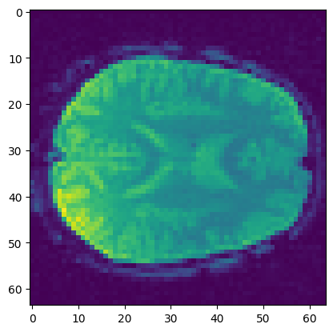

```python
plt.imshow(mri_array[2:4][0])
```

**Predicted MRI**

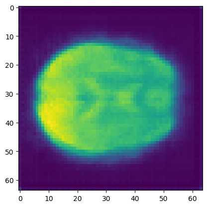

```python
plt.imshow(output[0]*(mri_array.max()-mri_array.min()))
```

```python
%load_ext tensorboard --logdir logs
```

### Important links for eeg dataset study:

https://iq.opengenus.org/eeg-signal-analysis-with-python/  
https://medium.com/@vishal.mi19/processing-eeg-data-with-python-8036fd7336ca  
https://www.youtube.com/watch?v=_BdBJOOqMes&list=PLtGXgNsNHqPTgP9wyR8pmy2EuM2ZGHU5Z&index=1  
https://www.youtube.com/watch?v=oMhKIsmRsps&list=PLtGXgNsNHqPTgP9wyR8pmy2EuM2ZGHU5Z&index=14